# WTSH QAQC

Max Czapanskiy

November 9, 2016

## Background

The purpose of this document is to validate the quality of dives from CEFAS tags. The `dive-identification-wtsh.R` script identifies *likely* dives and outputs dive plots and stats. The shiny app found in `WERC-SC\dive_identification\QAQC` is an interface for visually verifying dives. The output is a CSV with three pieces of information:

1. Dive quality. Either True, False, or Unclear.
2. Plunge error. Whether or not the max depth is artificially inflated by plunging or kicking.
3. Split error. Whether or not a single dive was split by an artifically shallow point.

An example is shown here:

```r
EmmaQAQC <- read.csv('www/WTSH_QAQC_ECK.csv')
head(EmmaQAQC)
```

```
##   DeployID EventID DiveID Index ValidDive SurfCal PlungeErr SplitErr Eyes
## 1      269     932      1     7         t     min     FALSE    FALSE TRUE
## 2      269     946      2     8         t     min     FALSE    FALSE TRUE
## 3      269    1088      3     1         t     min     FALSE    FALSE TRUE
## 4      269    1181      4     2         t     min     FALSE    FALSE TRUE
## 5      269    1185      5     3         t     min     FALSE    FALSE TRUE
## 6      269    1186      6     4         t     min     FALSE    FALSE TRUE
```

## Results

Jon, Emma, and I each ran the QAC tool. I summarized dive quality as the average of our three assessments, where False = 0, Unclear = 1, and True = 2. We excluded the dives from Deploy IDs 751 and 822 because they were unreliable.

```r
# Assumes the only files in www that begin "WTSH_QAQC_" are QAQC results
qaqc <- dir('www', pattern = 'WTSH_QAQC_', full.names = TRUE) %>%
  lapply(read.csv, stringsAsFactors = FALSE) %>%
  bind_rows %>%
  # TDRs from 751 and 822 were buggy
  filter(DeployID != 751,
         DeployID != 822) %>%
  # Order ValidDive from false to unclear to true
  mutate(ValidDive2 = recode(ValidDive,
                             f = 0,
                             u = 1,
                             t = 2)) %>%
  group_by(DeployID, DiveID) %>%
  # Assumes 3 QAQC files
  summarize(DiveQuality = sum(ValidDive2) / 3,
            PlungeErr = any(PlungeErr),
            SplitErr = any(SplitErr))

head(qaqc)
```

```
## Source: local data frame [6 x 5]
## Groups: DeployID [1]
##
##   DeployID DiveID DiveQuality PlungeErr SplitErr
##      <int>  <int>       <dbl>     <lgl>    <lgl>
## 1      269      1    1.333333     FALSE    FALSE
## 2      269      2    2.000000     FALSE    FALSE
## 3      269      3    2.000000     FALSE    FALSE
## 4      269      4    2.000000     FALSE    FALSE
## 5      269      5    2.000000     FALSE    FALSE
## 6      269      6    2.000000     FALSE    FALSE
```

```r
summary(qaqc)
```

```
##     DeployID       DiveID        DiveQuality     PlungeErr
##  Min.   :269   Min.   :  1.00   Min.   :0.3333   Mode :logical
##  1st Qu.:478   1st Qu.: 10.00   1st Qu.:1.3333   FALSE:1135
##  Median :824   Median : 26.00   Median :2.0000   TRUE :66
##  Mean   :674   Mean   : 35.66   Mean   :1.6847   NA's :0
##  3rd Qu.:844   3rd Qu.: 56.00   3rd Qu.:2.0000
##  Max.   :915   Max.   :138.00   Max.   :2.0000
##   SplitErr
##  Mode :logical
##  FALSE:1125
##  TRUE :76
##  NA's :0
##
##
```

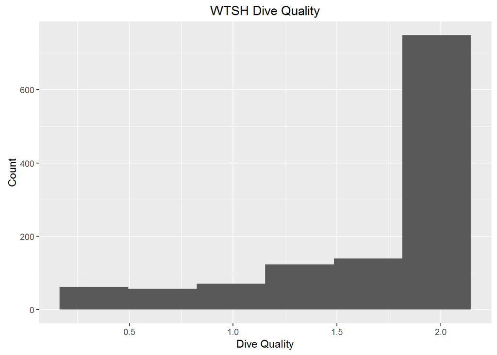

```r
ggplot(qaqc, aes(x = DiveQuality)) +
  geom_histogram(binwidth = .33) +
  labs(title = "WTSH Dive Quality",
       x = "Dive Quality",
       y = "Count")
```

## Next Steps

The above tables and histogram show that most of our dives are excellent quality. We need to decide where our threshold lies. Do we only use the unanimous dives? >1.5?

Also, there are 76 split errors and 66 plunge errors. I’ll manually make a reference file that has correct durations and maximum depths.